# Analyses of “Comparison of seroprevalence in locations monitored during the GI.1 and GI.2 periods”

Simone Santoro

2023-09-28

## Required libraries

```r
library(ggplot2)
library(ggeffects)
library(glmmTMB)
library(DHARMa)
library(dplyr)
library(AICcmodavg)
```

## Loading the database

The dataset comprises 36 observations that are distributed across 18 locations. These locations were monitored during two distinct periods: the GI.1 outbreak and the GI.2 outbreak. Except for one location (San Ignacio del Viar), data on the number of rabbits testing negative and positive for GI is available for all locations during both periods. Additionally, an abundance index (the count of latrines observed over linear transects that are four kilometers long) is available for 10 locations during GI.1 and 11 locations during GI.2. There are a total of 20 records that contain complete information on serological status and the abundance index, with 9 records from the GI.1 period and 11 records from the GI.2 period.

```r
rabbits <- read.table("serolRabbitsLetrinas.txt", header = TRUE, sep = "\t", stringsAsFactors = TRUE)
rabbits <- rabbits %>%
    mutate(ratio = pos / (pos + neg))
rabbits$ab.indexST<- as.numeric(scale(rabbits$ab.index))# this way the estimates of the model which include ab.index as covariate are meant for the average value of ab.index in the dataset
```

## Hypothesis 1: Is there a difference in Abundance Between GI.1 and GI.2 Outbreak Periods?

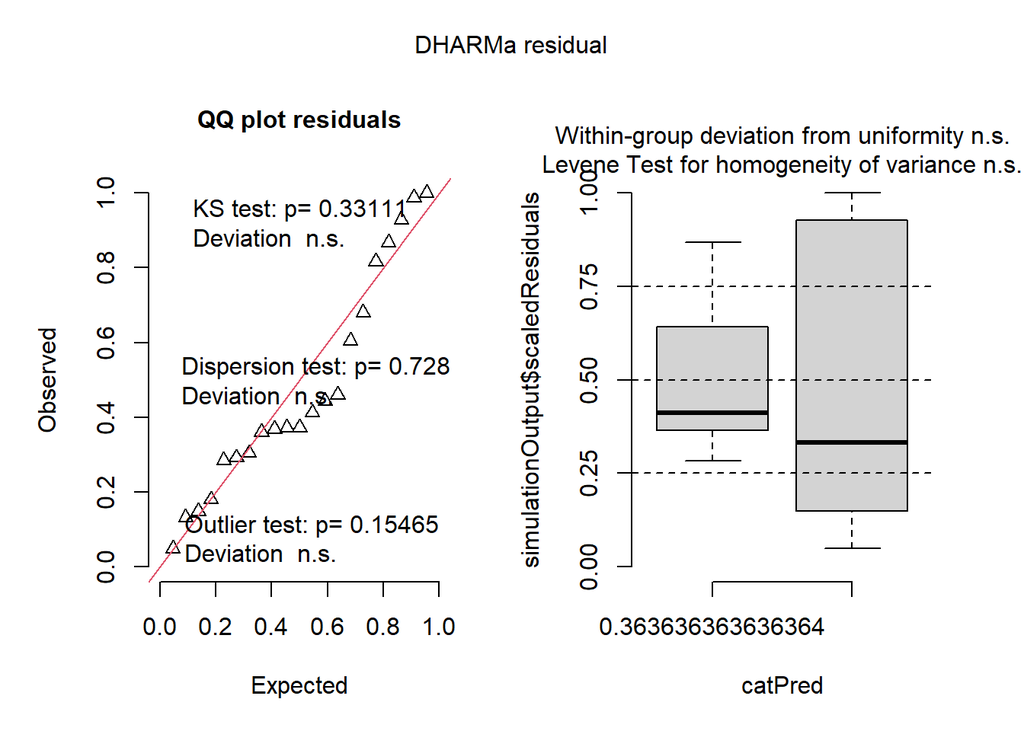

```
## Object of Class DHARMa with simulated residuals based on 250 simulations with refit = FALSE . See ?DHARMa::simulateResiduals for help.
##
## Scaled residual values: 0.148 0.604 0.444 0.36 0.132 0.46 0.928 0.868 1 0.412 0.048 0.368 0.18 0.372 0.988 0.304 0.284 0.292 0.68 0.372 ...
```

```r
# Keeping only the rows where ab.index is a non-NA
rabbitss<- rabbits[complete.cases(rabbits$ab.index),]
glmm1<- glmmTMB(ab.index ~ period + (1|location), data=rabbits)
simulateResiduals(glmm1,plot = T)
```

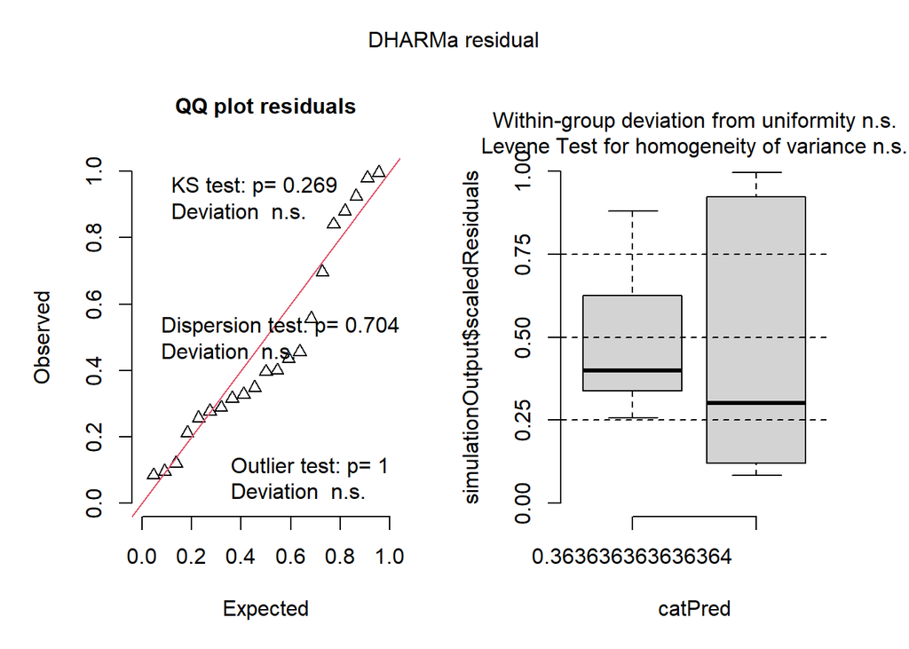

```
## Object of Class DHARMa with simulated residuals based on 250 simulations with refit = FALSE . See ?DHARMa::simulateResiduals for help.
##
## Scaled residual values: 0.12 0.556 0.436 0.328 0.096 0.456 0.924 0.88 0.996 0.396 0.084 0.348 0.212 0.4 0.98 0.276 0.256 0.288 0.696 0.316 ...
```

```r
glm1<- glmmTMB(ab.index ~ period, data=rabbits)
simulateResiduals(glm1,plot = T)
```

```r
AICc(glmm1)
```

```
## [1] 253.8639
```

```r
AICc(glm1)
```

```
## [1] 250.7757
```

```r
dif.AICc1<- round(AICc(glmm1)-AICc(glm1),2)

no.lat.GI.1<- round(as.numeric(fixef(glm1)[[1]][1]),2)
dif.lat.GI.2<- round(as.numeric(fixef(glm1)[[1]][2]),2)
glm1Null<- glmmTMB(ab.index ~ 1, data=rabbits)
glm1LRT<- anova(glm1,glm1Null,test="LRT")
glm1p<- ifelse(glm1LRT$`Pr(>Chisq)`[2]<0.01,"< 0.01",round(glm1LRT$`Pr(>Chisq)`[2],3))

summary(glm1)
```

```
##  Family: gaussian  ( identity )
## Formula:          ab.index ~ period
## Data: rabbits
##
##      AIC      BIC   logLik deviance df.resid
##    249.4    252.5   -121.7    243.4       18
##
##
## Dispersion estimate for gaussian family (sigma^2): 6.32e+03
##
## Conditional model:
##             Estimate Std. Error z value Pr(>|z|)
## (Intercept)   125.90      25.13   5.010 5.46e-07 ***
## periodGI.2    -58.17      34.72  -1.675   0.0939 .
## ---
## Signif. codes:  0 '***' 0.001 '**' 0.01 '*' 0.05 '.' 0.1 ' ' 1
```

Using location as random intercept is not supported by AICc (AICc difference of 3.09 units). Therefore, we used a GLM which indicates that the average number of latrines counted over 4-km long linear transects during the GI.1 period (approximately 125.9) was -58.17 higher than during the GI.2 period. However, this difference was statistically non-significant **(p = 0.105)** according to a likelihood ratio test.

## Hypothesis 2: Is There a Difference in Seroprevalence Between the GI.1 and GI.2 Outbreak Periods?

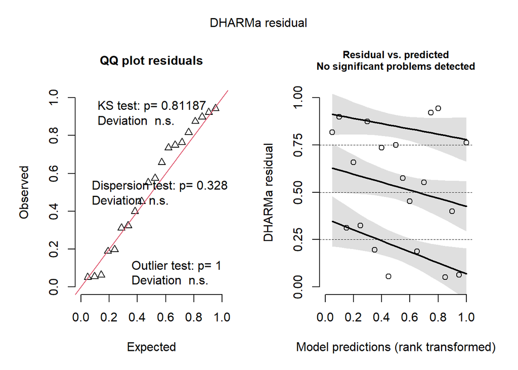

```
## Object of Class DHARMa with simulated residuals based on 250 simulations with refit = FALSE . See ?DHARMa::simulateResiduals for help.
##
## Scaled residual values: 0.7351325 0.1878232 0.3118282 0.3986728 0.1967137 0.552064 0.8983857 0.7500047 0.816329 0.9221121 0.05511872 0.05042832 0.8747852 0.9438461 0.06265589 0.7629747 0.3233139 0.45224 0.6581751 0.574554 ...
```

```r
glmm2<- glmmTMB(cbind(pos,neg) ~ period + ab.indexST + (1|location), data=rabbits,binomial)
simulateResiduals(glmm2,plot = T)
```

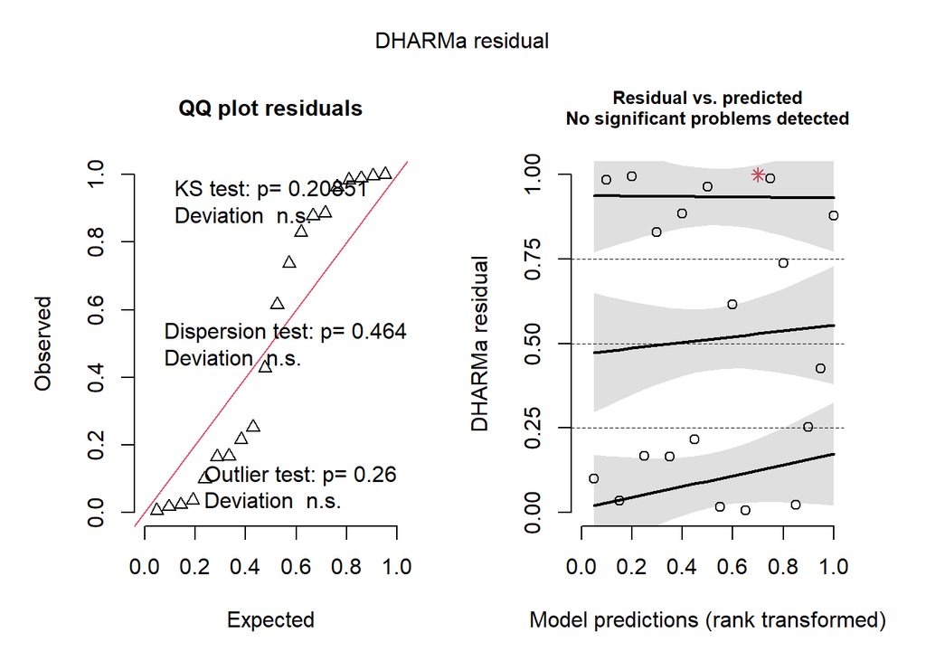

```
## Object of Class DHARMa with simulated residuals based on 250 simulations with refit = FALSE . See ?DHARMa::simulateResiduals for help.
##
## Scaled residual values: 0.983705 0.02286849 0.164635 0.6146401 0.03547171 0.7375347 0.8851972 0.8785552 0.2154946 0.9890748 0.09981237 0.005961023 0.9954592 1 0.01691801 0.9632682 0.1670466 0.2525167 0.8293612 0.4269486 ...
```

```r
glm2<- glmmTMB(cbind(pos,neg) ~ period + ab.indexST, data=rabbits,binomial)
simulateResiduals(glm2,plot = T)
```

```r
AICc(glmm2)
```

```
## [1] 117.7251
```

```r
AICc(glm2)
```

```
## [1] 133.5112
```

```r
(dif.AICc2<- round(AICc(glmm2)-AICc(glm2),2))
```

```
## [1] -15.79
```

```r
glmm2Null<- glmmTMB(cbind(pos,neg) ~ 1 + ab.indexST + (1|location), data=rabbits,binomial)
glmm2LRT<- anova(glmm2,glmm2Null,test="LRT")
glmm2p<- ifelse(glmm2LRT$`Pr(>Chisq)`[2]<0.01,"< 0.01",round(glmm2LRT$`Pr(>Chisq)`[2],3))

summary(glmm2)
```

```
##  Family: binomial  ( logit )
## Formula:          cbind(pos, neg) ~ period + ab.indexST + (1 | location)
## Data: rabbits
##
##      AIC      BIC   logLik deviance df.resid
##    115.1    119.0    -53.5    107.1       16
##
## Random effects:
##
## Conditional model:
##  Groups   Name        Variance Std.Dev.
##  location (Intercept) 0.6814   0.8255
## Number of obs: 20, groups:  location, 11
##
## Conditional model:
##             Estimate Std. Error z value Pr(>|z|)
## (Intercept)  -0.4244     0.3053  -1.390    0.164
## periodGI.2    0.9578     0.2328   4.115 3.87e-05 ***
## ab.indexST   -0.2102     0.2073  -1.014    0.311
## ---
## Signif. codes:  0 '***' 0.001 '**' 0.01 '*' 0.05 '.' 0.1 ' ' 1
```

Using location as random intercept is substantially supported by AICc (AICc difference of 15.79 units).

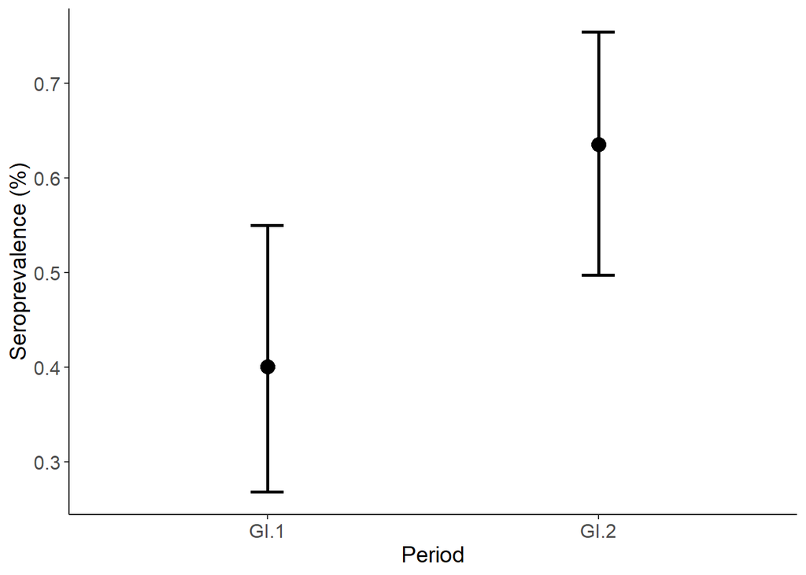

Figure 1. Study areas’ seroprevalence during the GI.1 and GI.2 outbreaks

```r
# Calculate predicted probabilities and confidence intervals
effects1 <- ggpredict(glmm2, terms = "period")
newdata1 <- data.frame(
  period = effects1$x,
  predicted = effects1$predicted,
  conf.low = effects1$conf.low,
  conf.high = effects1$conf.high
)

# Create a ggplot figure
ggplot(newdata1, aes(x = period, y = predicted)) +
  geom_point(size = 4) +  # Adjust point size
  geom_errorbar(aes(ymin = conf.low, ymax = conf.high), width = 0.1, linewidth = 1) +  # Adjust error bar width and size
  labs(
    x = "Period",
    y = "Seroprevalence (%)"
  ) +
  theme_classic() +
  theme(
    axis.title = element_text(size = 14),  # Adjust axis label size
    axis.text = element_text(size = 12),   # Adjust axis text size
  )
```

Therefore, we used a GLMM which indicates that the seroprevalence during the GI.1 period was 0.4 (95%CI: 0.27-0.55) whereas it was **significantly higher (p = < 0.01) during the GI.2 period** when it was (0.64, 95%CI: 0.5-0.75).

## Hypothesis 3: abundance affects seroprevalence during the GI.1 or GI.2 period

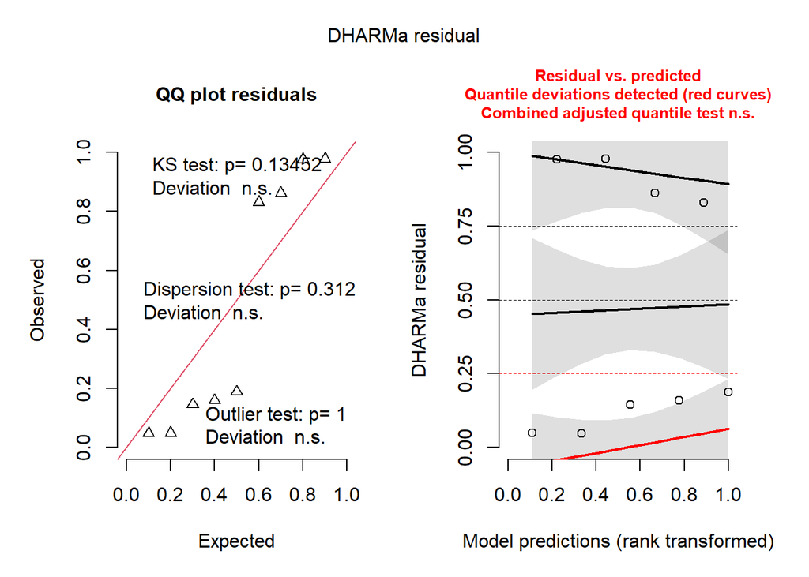

```
## Object of Class DHARMa with simulated residuals based on 250 simulations with refit = FALSE . See ?DHARMa::simulateResiduals for help.
##
## Scaled residual values: 0.9754296 0.1593661 0.0474419 0.8301756 0.1879083 0.0490716 0.9775326 0.145109 0.8622668
```

```r
glmm3GI1<- glm(cbind(pos,neg) ~ ab.index, data=rabbits[rabbits$period=="GI.1" & !is.na(rabbits$ab.index),],binomial)
simulateResiduals(glmm3GI1,plot = T)
```

```r
glmm3GI1Null<- glm(cbind(pos,neg) ~ 1, data=rabbits[rabbits$period=="GI.1" & !is.na(rabbits$ab.index),],binomial)
glmm3GI1LRT<- anova(glmm3GI1,glmm3GI1Null,test="LRT")
glmm3GI1p<- ifelse(glmm3GI1LRT$`Pr(>Chi)`[2]<0.01,"< 0.01",round(glmm3GI1LRT$`Pr(>Chi)`[2],3))

summary(glmm3GI1)
```

```
##
## Call:
## glm(formula = cbind(pos, neg) ~ ab.index, family = binomial,
##     data = rabbits[rabbits$period == "GI.1" & !is.na(rabbits$ab.index),
##         ])
##
## Coefficients:
##              Estimate Std. Error z value Pr(>|z|)
## (Intercept) -0.583929   0.239853  -2.435   0.0149 *
## ab.index     0.002404   0.001624   1.480   0.1388
## ---
## Signif. codes:  0 '***' 0.001 '**' 0.01 '*' 0.05 '.' 0.1 ' ' 1
##
## (Dispersion parameter for binomial family taken to be 1)
##
##     Null deviance: 22.416  on 8  degrees of freedom
## Residual deviance: 20.213  on 7  degrees of freedom
##   (1 observation deleted due to missingness)
## AIC: 52.939
##
## Number of Fisher Scoring iterations: 4
```

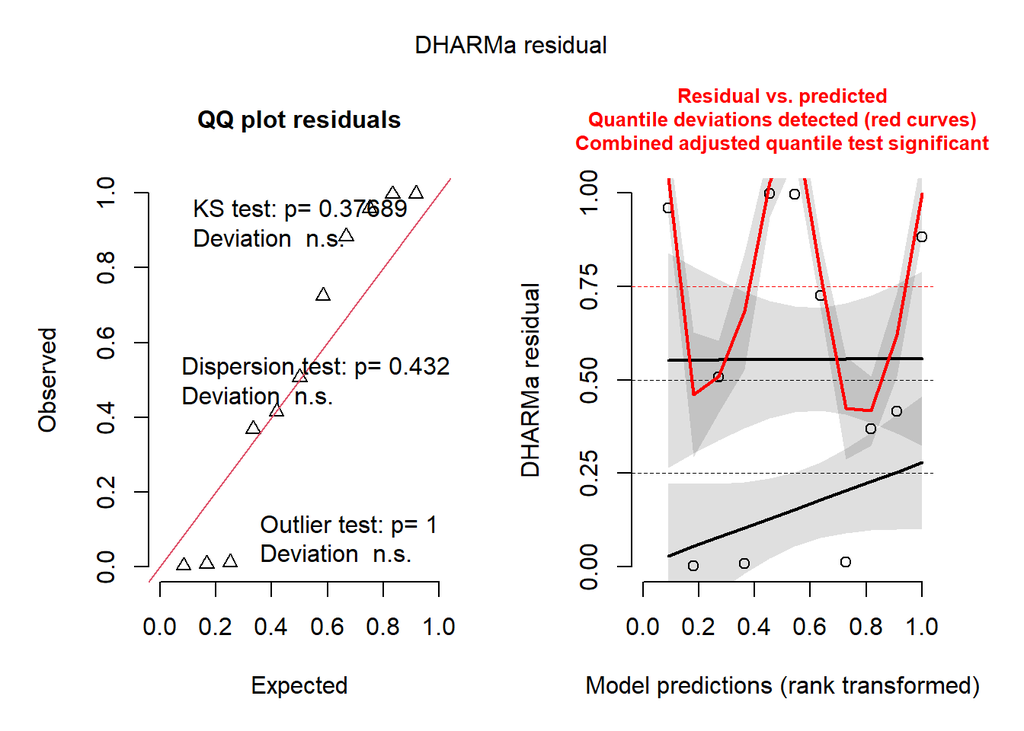

```
## Object of Class DHARMa with simulated residuals based on 250 simulations with refit = FALSE . See ?DHARMa::simulateResiduals for help.
##
## Scaled residual values: 0.012 0.507132 0.7252402 0.8832263 0.9971621 0.008 0.9977618 0.002368886 0.9599242 0.3689358 0.415691
```

```r
glmm3GI2<- glm(cbind(pos,neg) ~ ab.index, data=rabbits[rabbits$period=="GI.2" & !is.na(rabbits$ab.index),],binomial)
simulateResiduals(glmm3GI2,plot = T)
```

```r
glmm3GI2Null<- glm(cbind(pos,neg) ~ 1, data=rabbits[rabbits$period=="GI.2" & !is.na(rabbits$ab.index),],binomial)
glmm3GI2LRT<- anova(glmm3GI2,glmm3GI2Null,test="LRT")
glmm3GI2p<- ifelse(glmm3GI2LRT$`Pr(>Chi)`[2]<0.01,"< 0.01",round(glmm3GI2LRT$`Pr(>Chi)`[2],3))

summary(glmm3GI2)
```

```
##
## Call:
## glm(formula = cbind(pos, neg) ~ ab.index, family = binomial,
##     data = rabbits[rabbits$period == "GI.2" & !is.na(rabbits$ab.index),
##         ])
##
## Coefficients:
##             Estimate Std. Error z value Pr(>|z|)
## (Intercept) 0.387424   0.251841   1.538    0.124
## ab.index    0.001700   0.003129   0.543    0.587
##
## (Dispersion parameter for binomial family taken to be 1)
##
##     Null deviance: 41.745  on 10  degrees of freedom
## Residual deviance: 41.448  on  9  degrees of freedom
## AIC: 81.032
##
## Number of Fisher Scoring iterations: 4
```

Although the model’s estimate suggest a positive relationship between abundance and seroprevalence, we found no support to this hypothesis neither during the GI.1 period **(p = 0.138)** nor the GI.2 period **(p = 0.586)** (Figure 3).

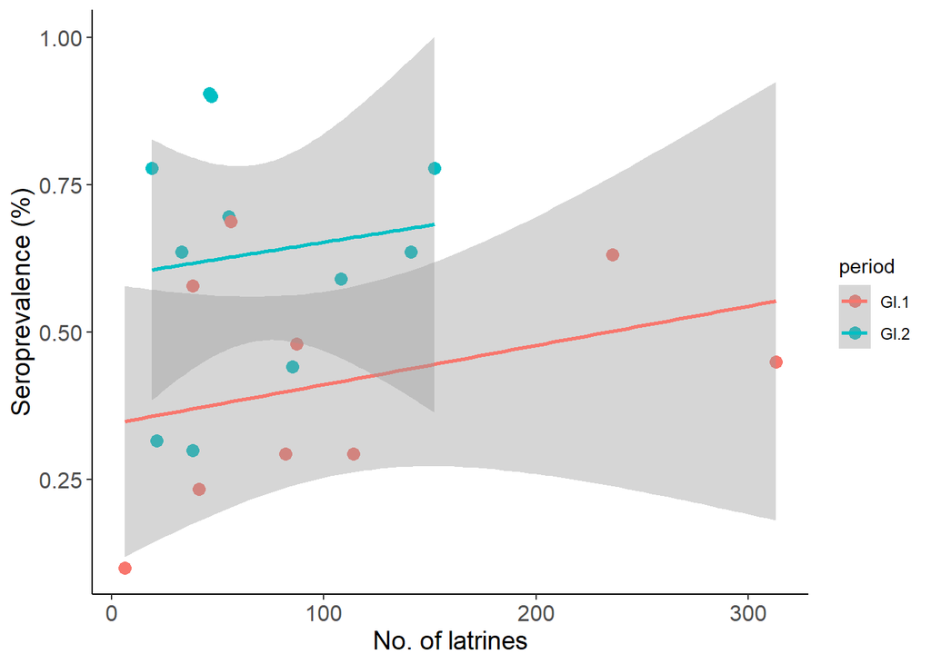

Figure 3. Study areas’ relationship between abundance and seroprevalence during the GI.1 and GI.2 outbreak

```r
ggplot(rabbits, aes(x = ab.index, y = pos / (pos + neg), color = period))+
  geom_point(size = 3)+
  geom_smooth(method = "lm", se = TRUE)+
  labs(
    x = "No. of latrines",
    y = "Seroprevalence (%)"
  )+
  theme_classic()+
  theme(
    axis.title = element_text(size = 14),
    axis.text = element_text(size = 12)
  )
```